NB-FOXR2 project [[source](https://github.com/fungenomics/NB-FOXR2)]

# 08 - Extracranial neuroblastoma

Selin Jessa [selin.jessa@mail.mcgill.ca] and Bhavyaa Chandarana [bhavyaa.chandarana@mail.mcgill.ca]

05 November, 2024

# 1 Configuration

Configuration of project directory & analysis outputs:

**Show full config**

```r
source(here("rr_helpers.R"))

# Set up outputs
message("Document index: ", doc_id)
```

```
## Document index: 08
```

```r
# Specify where to save outputs
out        <- here("output", doc_id); dir.create(out, recursive = TRUE)
figout     <- here("figures", doc_id, "/")
cache      <- paste0("/project/kleinman/bhavyaa.chandarana/cache/NB-FOXR2/public/", doc_id, "/")
```

The root directory of this project is:

```
## /project/kleinman/bhavyaa.chandarana/from_hydra/2023-05-NB-FOXR2/public
```

Outputs and figures will be saved at these paths, relative to project root:

```
## public/output/08
```

```
## public/figures/08//
```

Setting a random seed:

```r
set.seed(100)
```

# 2 Overview

This document compares NB-FOXR2 with extracranial neuroblastoma samples stratified by stage and FOXR2 expression.

# 3 Libraries

```r
library(here)
library(magrittr)
library(tidyr)
library(dplyr)
library(readr)
library(readxl)
library(stringr)
library(glue)
library(purrr)
library(ggplot2)
library(ggrepel)
library(tibble)
library(cowplot)
library(Seurat)
library(data.table)
library(MetBrewer)
library(dendextend)
library(readxl)
library(GSVA)
library(clusterProfiler)
library(org.Hs.eg.db)
library(GO.db)
library(ComplexHeatmap)

source(here("include/style.R"))
source(here("code/functions/RNAseq.R"))
source(here("code/functions/scRNAseq.R"))
source(here("code/functions/ssGSEA.R"))

ggplot2::theme_set(theme_min())

square_theme <- theme(aspect.ratio = 1)
large_text <- theme(text = element_text(size = 15))

conflicted::conflicts_prefer(dplyr::select)
conflicted::conflicts_prefer(dplyr::filter)
conflicted::conflicts_prefer(dplyr::first)
conflicted::conflicts_prefer(dplyr::last)
conflicted::conflicts_prefer(dplyr::combine)
conflicted::conflicts_prefer(dplyr::intersect)
conflicted::conflicts_prefer(base::setdiff)
conflicted::conflicts_prefer(clusterProfiler::slice)
conflicted::conflicts_prefer(dplyr::rename)
conflicted::conflicts_prefer(dplyr::desc)
conflicted::conflicts_prefer(dplyr::filter)
```

# 4 Load EC-NB samples

## 4.1 Gartlgruber et al. 2021 (n=579)

Publication: [Gartlgruber et al. *Nature Cancer* 2021](https://pubmed.ncbi.nlm.nih.gov/35121888/)

### 4.1.1 Load data

This data was downloaded from a Shiny app provided by the authors of the study.

Data was provided as un-normalized bulk counts and per-tumor metadata.

Load DESeq normalized counts produced in in R markdown document `03` for plotting gene expression.

```r
# Load files and remove unused ones to save space
load(here("output/03/Gartlgruber_et_al_counts.Rda"))
rm(ecnb_counts_norm)
rm(ecnb_counts_vst)
```

### 4.1.2 Add FOXR2 positivity to metadata

Here, we label each tumor as FOXR2 positive or negative in per-tumor metadata based on normalized expression of FOXR2. We consider tumors with FOXR2 DESeq normalized expression > 2 to be FOXR2 positive.

```r
# Set threshold of FOXR2+ expression used throughout this document
threshold <- 2

ecnb_foxr2_counts <- ecnb_counts_tidy %>%
    filter(gene_symbol == "FOXR2")

foxr2_pos_samples <- ecnb_foxr2_counts %>%
    filter(gene_expression > threshold) %>%
    .$sample

ecnb_foxr2_counts <- ecnb_foxr2_counts %>% mutate(FOXR2_positive = case_when(sample %in% foxr2_pos_samples ~ "Y",
                                      T ~ "N"))

# Print the number of FOXR2 positive and negative samples
ecnb_foxr2_counts %>% count(FOXR2_positive, sort = F)
```

| FOXR2_positive | n |
| --- | --- |
| N | 473 |
| Y | 106 |

```r
# Print the number of FOXR2 positive and negative samples in each tumor stage
ecnb_foxr2_counts %>% count(Stage, FOXR2_positive, sort = F)
```

| Stage | FOXR2_positive | n |
| --- | --- | --- |
| 1-3;4S | N | 292 |
| 1-3;4S | Y | 41 |
| 4 | N | 171 |
| 4 | Y | 58 |
| NA | N | 10 |
| NA | Y | 7 |

```r
ecnb_counts_tidy <- ecnb_counts_tidy %>%
    mutate(FOXR2_positive = case_when(sample %in% foxr2_pos_samples ~ "FOXR2+",
                                      T ~ "FOXR2-"))
```

## 4.2 TARGET cohort (n=128)

Downloaded and processed by Steven Hébert in April 2024.

They were downloaded as count matrices from the public Genomic 686 Data Commons (GDC) cancer portal (https://portal.gdc.cancer.gov/) using the Cohort Builder, with options:

- `project = TARGET-346 NBL`
- `Experimental Strategy = RNA-seq`
- `Access = open`

### 4.2.1 Load data

Patients were subsetted to Risk = HR (high risk) and Stage = 3 or 4 (not 4S). This resulted in a total of 128 patient samples.

Load patient sample metadata.

```r
# Load, replace the empty value '-- with NA values and remove all-NA columns,
# and rename id column to Sample
target_meta <- data.table::fread(here("data/RNAseq/external_data/TARGET_ECNB/clinical.tsv")) %>%
    apply(2,
              function(col) {
                  gsub(col, pattern = "'--", replacement = as.character(NA))
              }
          ) %>%
    as.data.frame() %>%
    select_if(~ !all(is.na(.))) %>%
    dplyr::rename(Sample = case_submitter_id)
```

Load DESeq-normalized counts (for plotting gene expression).

```r
# load normalized counts
target_norm <- here("data/RNAseq/external_data/TARGET_ECNB/counts_ensembl_common/GENCODEv36.norm.tsv.gz") %>%
    read.table(header = T, row.names = 1, check.names = F, sep = "\t")

# Display first 5 row/col to check
target_norm[1:5, 1:5]
```

|  | TARGET-30-PAIFXV-01A | TARGET-30-PAIPGU-01A | TARGET-30-PAISNS-01A | TARGET-30-PAITCI-01A | TARGET-30-PAITEG-01A |
| --- | --- | --- | --- | --- | --- |
| ENSG00000000003:TSPAN6 | 1612.983582 | 1337.289410 | 3232.9537 | 1649.4543 | 1697.629906 |
| ENSG00000000005:TNMD | 9.170469 | 8.985147 | 0.0000 | 0.0000 | 0.607381 |
| ENSG00000000419:DPM1 | 1610.945700 | 2105.519496 | 2272.0982 | 4908.1899 | 2858.335005 |
| ENSG00000000457:SCYL3 | 543.095546 | 489.690523 | 816.3660 | 655.7644 | 368.680269 |
| ENSG00000000460:C1orf112 | 177.295732 | 371.386085 | 686.3254 | 309.5681 | 126.335249 |

### 4.2.2 Add FOXR2 positivity to metadata

Based on threshold = 2.

```r
# DESeq norm expression threshold used for FOXR2 +/-
threshold <- 2

target_counts_tidy <- target_norm %>%
    as.data.frame() %>%
    rownames_to_column("Gene") %>%
    separate(col = "Gene", sep = ":", into = c("ENS", "gene_symbol")) %>%
    pivot_longer(cols = -c("ENS", "gene_symbol"), names_to = "ID", values_to = "gene_expression")

foxr2_pos_samples_target <- target_counts_tidy %>%
    filter(gene_symbol == "FOXR2") %>%
    filter(gene_expression > threshold) %>%
    .$ID

target_meta_foxr2 <- target_counts_tidy %>%
    mutate(FOXR2_positive = case_when(ID %in% foxr2_pos_samples_target ~ "Y",
                                      T ~ "N")) %>%
    select(ID, FOXR2_positive) %>% distinct
```

# 5 FOXR2 coexpression with MGE TFs in EC-NB

## 5.1 Gartlgruber et al. 2021

Stage 4, high-risk tumors only. (Samples with NA in either Risk or Stage metadata columns are removed.)

```r
tum_interest <- ecnb_counts_tidy %>%
    filter(Risk == "HR") %>%
    filter(Stage == "4") %>%
    filter(gene_symbol %in% c("FOXR2", "LHX6", "DLX5", "DLX6"))

# DLX5
foxr2_dlx5 <- tum_interest %>%
    filter(gene_symbol %in% c("FOXR2", "DLX5")) %>%
    pivot_wider(names_from = "gene_symbol",
                values_from = "gene_expression",
                id_cols = c("sample", "FOXR2_positive"))

(cor_foxr2_dlx5 <- cor(foxr2_dlx5$FOXR2, foxr2_dlx5$DLX5, method = "pearson"))
```

```
## [1] 0.1477744
```

```r
(sig_dlx5 <- wilcox.test(foxr2_dlx5 %>% filter(FOXR2_positive == "FOXR2+") %>% .$DLX5,
                         foxr2_dlx5 %>% filter(FOXR2_positive == "FOXR2-") %>% .$DLX5))
```

```
##
##  Wilcoxon rank sum test with continuity correction
##
## data:  foxr2_dlx5 %>% filter(FOXR2_positive == "FOXR2+") %>% .$DLX5 and foxr2_dlx5 %>% filter(FOXR2_positive == "FOXR2-") %>% .$DLX5
## W = 3549, p-value = 0.8924
## alternative hypothesis: true location shift is not equal to 0
```

```r
dlx5_scatter <- foxr2_dlx5 %>%
    ggplot(aes(x = FOXR2, y = DLX5, alpha = 0.2)) +
    geom_point(alpha = 0.5, size = 3) +
    ggtitle("DLX5 - EC-NB stage 4") +
    annotate("text", label = glue("r == {round(cor_foxr2_dlx5,4)}"),
             x = 470, y = 4000, parse = T)

dlx5_vln <- foxr2_dlx5 %>%
    ggplot(aes(x = FOXR2_positive, y = DLX5, fill = FOXR2_positive)) +
    geom_violin(scale = "width") +
    ggtitle("DLX5 - EC-NB stage 4") +
    no_legend() + scale_y_log10() +
    stat_summary(fun.y=median, geom="crossbar", size=1,
                 color="black", aes(width = 0.3)) +
    annotate("text", label = glue("p == {round(sig_dlx5$p.value,4)}"),
             x = 2, y = 4000, parse = T)


# DLX6
foxr2_dlx6 <- tum_interest %>%
    filter(gene_symbol %in% c("FOXR2", "DLX6")) %>%
    pivot_wider(names_from = "gene_symbol",
                values_from = "gene_expression",
                id_cols = c("sample", "FOXR2_positive"))

(cor_foxr2_dlx6 <- cor(foxr2_dlx6$FOXR2, foxr2_dlx6$DLX6, method = "pearson"))
```

```
## [1] 0.2062904
```

```r
(sig_dlx6 <- wilcox.test(foxr2_dlx6 %>% filter(FOXR2_positive == "FOXR2+") %>% .$DLX6,
                         foxr2_dlx6 %>% filter(FOXR2_positive == "FOXR2-") %>% .$DLX6))
```

```
##
##  Wilcoxon rank sum test with continuity correction
##
## data:  foxr2_dlx6 %>% filter(FOXR2_positive == "FOXR2+") %>% .$DLX6 and foxr2_dlx6 %>% filter(FOXR2_positive == "FOXR2-") %>% .$DLX6
## W = 3461.5, p-value = 0.6946
## alternative hypothesis: true location shift is not equal to 0
```

```r
dlx6_scatter <- foxr2_dlx6 %>%
    ggplot(aes(x = FOXR2, y = DLX6, alpha = 0.2)) +
    geom_point(alpha = 0.5, size = 3) + ggtitle("DLX6 - EC-NB stage 4") +
    annotate("text", label = glue("r == {round(cor_foxr2_dlx6,4)}"),
             x = 470, y = 3000, parse = T)

dlx6_vln <- foxr2_dlx6 %>%
    ggplot(aes(x = FOXR2_positive, y = DLX6, fill = FOXR2_positive)) +
    geom_violin(scale = "width") +
    ggtitle("DLX6 - EC-NB stage 4") +
    no_legend() + scale_y_log10() +
    stat_summary(fun.y=median, geom="crossbar", size=1,
                 color="black", aes(width = 0.3))  +
    annotate("text", label = glue("p == {round(sig_dlx6$p.value,4)}"),
             x = 2, y = 4000, parse = T)



# LHX6
foxr2_lhx6 <- tum_interest %>%
    filter(gene_symbol %in% c("FOXR2", "LHX6")) %>%
    pivot_wider(names_from = "gene_symbol",
                values_from = "gene_expression",
                id_cols = c("sample", "FOXR2_positive"))

(cor_foxr2_lhx6 <- cor(foxr2_lhx6$FOXR2, foxr2_lhx6$LHX6, method = "pearson"))
```

```
## [1] -0.04012718
```

```r
(sig_lhx6 <- wilcox.test(foxr2_lhx6 %>% filter(FOXR2_positive == "FOXR2+") %>% .$LHX6,
                         foxr2_lhx6 %>% filter(FOXR2_positive == "FOXR2-") %>% .$LHX6))
```

```
##
##  Wilcoxon rank sum test with continuity correction
##
## data:  foxr2_lhx6 %>% filter(FOXR2_positive == "FOXR2+") %>% .$LHX6 and foxr2_lhx6 %>% filter(FOXR2_positive == "FOXR2-") %>% .$LHX6
## W = 3546, p-value = 0.8854
## alternative hypothesis: true location shift is not equal to 0
```

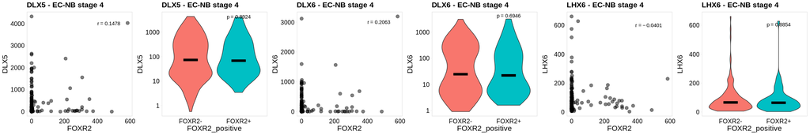

```r
lhx6_scatter <- foxr2_lhx6 %>%
    ggplot(aes(x = FOXR2, y = LHX6, alpha = 0.2)) +
    geom_point(alpha = 0.5, size = 3) +
    ggtitle("LHX6 - EC-NB stage 4") +
    annotate("text", label = glue("r == {round(cor_foxr2_lhx6,4)}"),
             x = 470, y = 600, parse = T)

lhx6_vln <- foxr2_lhx6 %>%
    ggplot(aes(x = FOXR2_positive, y = LHX6, fill = FOXR2_positive)) +
    geom_violin(scale = "width") +
    ggtitle("LHX6 - EC-NB stage 4") +
    no_legend() +
    stat_summary(fun.y=median, geom="crossbar", size=1,
                 color="black", aes(width = 0.3))  +
    annotate("text", label = glue("p == {round(sig_lhx6$p.value,4)}"),
             x = 2, y = 600, parse = T)


cowplot::plot_grid(dlx5_scatter, dlx5_vln,
                                dlx6_scatter, dlx6_vln,
                                lhx6_scatter, lhx6_vln,
                   nrow = 1, align = "hv")
```

## 5.2 TARGET cohort

FOXR2 + threshold: DESEq normalized value "2".

```r
tum_interest <- target_counts_tidy %>%
    filter(gene_symbol %in% c("FOXR2", "LHX6", "DLX5", "DLX6")) %>%
    left_join(., target_meta_foxr2, by = "ID") %>%
    dplyr::rename("sample" = "ID") %>%
    mutate(FOXR2_positive = case_when(FOXR2_positive == "Y" ~ "FOXR2+",
                                      FOXR2_positive == "N" ~ "FOXR2-",
                                      TRUE ~ NA))

# DLX5
foxr2_dlx5 <- tum_interest %>%
    filter(gene_symbol %in% c("FOXR2", "DLX5")) %>%
    pivot_wider(names_from = "gene_symbol",
                values_from = "gene_expression",
                id_cols = c("sample", "FOXR2_positive"))

(cor_foxr2_dlx5 <- cor(foxr2_dlx5$FOXR2, foxr2_dlx5$DLX5, method = "pearson"))
```

```
## [1] 0.07350015
```

```r
(sig_dlx5 <- wilcox.test(foxr2_dlx5 %>% filter(FOXR2_positive == "FOXR2+") %>% .$DLX5,
                         foxr2_dlx5 %>% filter(FOXR2_positive == "FOXR2-") %>% .$DLX5))
```

```
##
##  Wilcoxon rank sum test with continuity correction
##
## data:  foxr2_dlx5 %>% filter(FOXR2_positive == "FOXR2+") %>% .$DLX5 and foxr2_dlx5 %>% filter(FOXR2_positive == "FOXR2-") %>% .$DLX5
## W = 1816, p-value = 0.2406
## alternative hypothesis: true location shift is not equal to 0
```

```r
dlx5_scatter <- foxr2_dlx5 %>%
    ggplot(aes(x = FOXR2, y = DLX5, alpha = 0.2)) +
    geom_point(alpha = 0.5, size = 3) +
    ggtitle("DLX5 - EC-NB stage 4") +
    annotate("text", label = glue("r == {round(cor_foxr2_dlx5,4)}"),
            x = 900, y = 5500, parse = T)

dlx5_vln <- foxr2_dlx5 %>%
    ggplot(aes(x = FOXR2_positive, y = DLX5, fill = FOXR2_positive)) +
    geom_violin(scale = "width") +
    ggtitle("DLX5 - EC-NB stage 4") +
    no_legend() + scale_y_log10() +
    stat_summary(fun.y=median, geom="crossbar", size=1,
                 color="black", aes(width = 0.3)) +
    annotate("text", label = glue("p == {round(sig_dlx5$p.value,4)}"),
             x = 2, y = 5500, parse = T)


# DLX6
foxr2_dlx6 <- tum_interest %>%
    filter(gene_symbol %in% c("FOXR2", "DLX6")) %>%
    pivot_wider(names_from = "gene_symbol",
                values_from = "gene_expression",
                id_cols = c("sample", "FOXR2_positive"))

(cor_foxr2_dlx6 <- cor(foxr2_dlx6$FOXR2, foxr2_dlx6$DLX6, method = "pearson"))
```

```
## [1] 0.1009971
```

```r
(sig_dlx6 <- wilcox.test(foxr2_dlx6 %>% filter(FOXR2_positive == "FOXR2+") %>% .$DLX6,
                         foxr2_dlx6 %>% filter(FOXR2_positive == "FOXR2-") %>% .$DLX6))
```

```
##
##  Wilcoxon rank sum test with continuity correction
##
## data:  foxr2_dlx6 %>% filter(FOXR2_positive == "FOXR2+") %>% .$DLX6 and foxr2_dlx6 %>% filter(FOXR2_positive == "FOXR2-") %>% .$DLX6
## W = 1823.5, p-value = 0.2248
## alternative hypothesis: true location shift is not equal to 0
```

```r
dlx6_scatter <- foxr2_dlx6 %>%
    ggplot(aes(x = FOXR2, y = DLX6, alpha = 0.2)) +
    geom_point(alpha = 0.5, size = 3) + ggtitle("DLX6 - EC-NB stage 4") +
    annotate("text", label = glue("r == {round(cor_foxr2_dlx6,4)}"),
              x = 900, y = 3500, parse = T)

dlx6_vln <- foxr2_dlx6 %>%
    ggplot(aes(x = FOXR2_positive, y = DLX6, fill = FOXR2_positive)) +
    geom_violin(scale = "width") +
    ggtitle("DLX6 - EC-NB stage 4") +
    no_legend() + scale_y_log10() +
    stat_summary(fun.y=median, geom="crossbar", size=1,
                 color="black", aes(width = 0.3))  +
    annotate("text", label = glue("p == {round(sig_dlx6$p.value,4)}"),
              x = 2, y = 3500, parse = T)



# LHX6
foxr2_lhx6 <- tum_interest %>%
    filter(gene_symbol %in% c("FOXR2", "LHX6")) %>%
    pivot_wider(names_from = "gene_symbol",
                values_from = "gene_expression",
                id_cols = c("sample", "FOXR2_positive"))

(cor_foxr2_lhx6 <- cor(foxr2_lhx6$FOXR2, foxr2_lhx6$LHX6, method = "pearson"))
```

```
## [1] -0.1011051
```

```r
(sig_lhx6 <- wilcox.test(foxr2_lhx6 %>% filter(FOXR2_positive == "FOXR2+") %>% .$LHX6,
                         foxr2_lhx6 %>% filter(FOXR2_positive == "FOXR2-") %>% .$LHX6))
```

```
##
##  Wilcoxon rank sum test with continuity correction
##
## data:  foxr2_lhx6 %>% filter(FOXR2_positive == "FOXR2+") %>% .$LHX6 and foxr2_lhx6 %>% filter(FOXR2_positive == "FOXR2-") %>% .$LHX6
## W = 1493, p-value = 0.5729
## alternative hypothesis: true location shift is not equal to 0
```

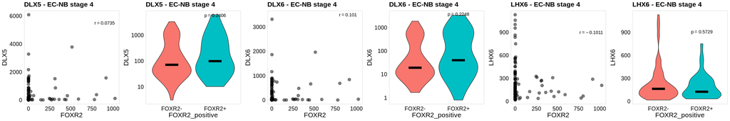

```r
lhx6_scatter <- foxr2_lhx6 %>%
    ggplot(aes(x = FOXR2, y = LHX6, alpha = 0.2)) +
    geom_point(alpha = 0.5, size = 3) +
    ggtitle("LHX6 - EC-NB stage 4") +
    annotate("text", label = glue("r == {round(cor_foxr2_lhx6,4)}"),
             x = 900, y = 900, parse = T)

lhx6_vln <- foxr2_lhx6 %>%
    ggplot(aes(x = FOXR2_positive, y = LHX6, fill = FOXR2_positive)) +
    geom_violin(scale = "width") +
    ggtitle("LHX6 - EC-NB stage 4") +
    no_legend() +
    stat_summary(fun.y=median, geom="crossbar", size=1,
                 color="black", aes(width = 0.3))  +
    annotate("text", label = glue("p == {round(sig_lhx6$p.value,4)}"),
             x = 2, y = 900, parse = T)


cowplot::plot_grid(dlx5_scatter, dlx5_vln,
                    dlx6_scatter, dlx6_vln,
                    lhx6_scatter, lhx6_vln,
                   nrow = 1, align = "hv")
```

# 6 Reproducibility

This document was last rendered on:

```
## 2024-11-05 10:34:07
```

The git repository and last commit:

```
## Local:    main /project/kleinman/bhavyaa.chandarana/from_hydra/2023-05-NB-FOXR2/public
## Remote:   main @ origin (https://github.com/fungenomics/NB-FOXR2.git)
## Head:     [72d1c5c] 2024-11-04: Add DOI badge
```

The random seed was set with `set.seed(100)`

A project of the Kleinman Lab at McGill University, using the [rr](https://github.com/sjessa/rr/) reproducible research template.